[figure not shown]

# COVID-19 Projections: Afghanistan

#### Report Date: 29 Jul 2020

This report summarizes the COVID-19 model results for Afghanistan, developed by the OCHA Centre for Humanitarian Data in partnership with the Johns Hopkins University Applied Physics Laboratory. These projections are based on COVID-19 cases and deaths data up to 2020-07-29. The data is sourced from WHO and the MOPH. For dynamic updates to this data and more, see the [HDX COVID-19 Map Explorer](https://data.humdata.org/visualization/covid19-humanitarian-operations/#). For additional information, please contact Leonardo Milano at: leonardo.milano@un.org.

(as of 29 Jul 2020)

- A total of 36,471 cases have been reported and 1,271 deaths reported.
- New reported cases and deaths have declined by 33% and 54% respectively with respect to last week.

(next 4 weeks or by 26 Aug 2020)

- A 5-7% projected increase in total cases assuming all current NPIs are maintained.
- An up to 10% projected increase in total deaths assuming all current NPIs are maintained.
- Lifting of NPIs would lead to a larger increase in cases and deaths (see sections 2 and 3 for details).
- Cases are expected to grow at a lower rate than projected in the last update.
- However, this is partially due to delays and gaps in reporting. The number of severe cases is expected to grow despite the predicted lower rate of increase in cases (see section 4).

(next 2 weeks or by 12 Aug 2020)

- A projected decrease in new cases in all the provinces apart from Parwan Province, assuming all current NPIs are maintained.
- A projected 4% increase in new cases in Parwan Province, assuming all current NPIs are maintained.

(as of 29 Jul 2020)[^1]

3.5%

38.8

[output not shown]

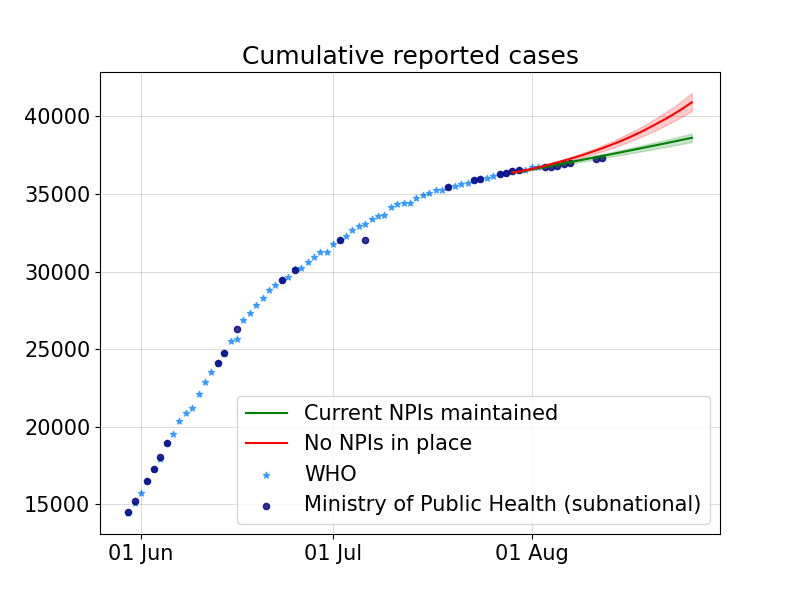

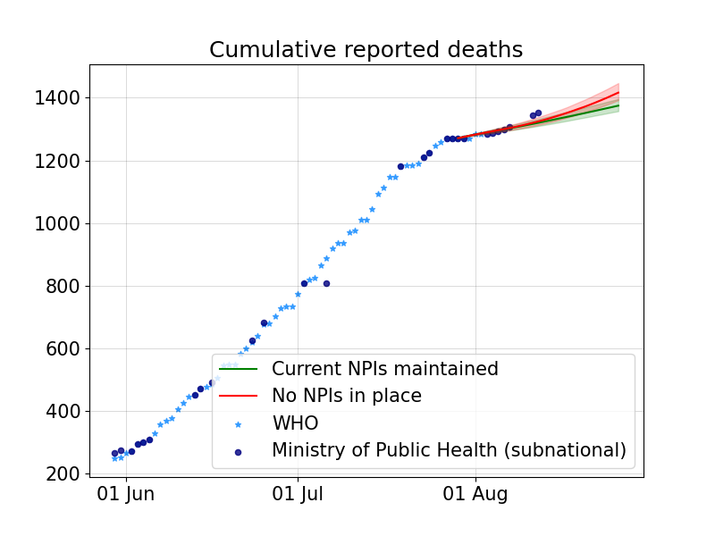

The figures above show the comparison between the reported case and data from two different sources (national level data from WHO in light blue and subnational data from the Ministry of Public Health in dark blue) together with the projected trends. The two lines presented correspond to ‘Current NPIs maintained’ and ‘No NPIs in place’ scenarios.

[^2]

## Estimate based on number of cases as of 2020-07-29

181 - 310

## Projected situation as of 2020-08-26

254 - 410

626 - 1,014

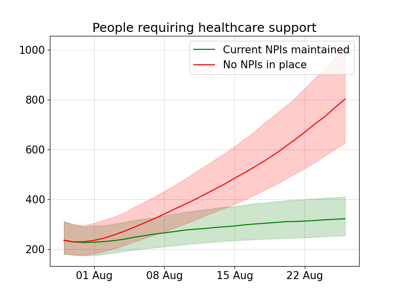